# FitbandHAR

Ramvyasa

7/8/2020

# Synopsis

Using data from accelerometers on the belt, forearm, arm, and dumbell of 6 participants who were asked to perform barbell lifts correctly and incorrectly in 5 different ways, we will predict the manner in which they did the exercise.

# Packages used

```r
library(caret)
```

# Getting the data

```r
download.file("https://d396qusza40orc.cloudfront.net/predmachlearn/pml-training.csv", "training.csv", method = "curl")
train <- read.csv("training.csv")
download.file("https://d396qusza40orc.cloudfront.net/predmachlearn/pml-testing.csv", "testing.csv", method = "curl")
test <- read.csv("testing.csv")
```

# Exploring the data

```r
differing <- match(FALSE,(names(test) == names(train)))
names(train)[differing]
```

```
## [1] "classe"
```

```r
names(test)[differing]
```

```
## [1] "problem_id"
```

We get to kniw the differing column from the two data sets are classe and problem id from train and test data sets respectively.

# Removing NA values

```r
keepCol <- (colSums(is.na(train)) < nrow(train)) & (colSums(is.na(test)) < nrow(test))
test <- test[,keepCol]
train <- train[,keepCol]
dim(train)
```

```
## [1] 19622    60
```

```r
dim(test)
```

```
## [1] 20 60
```

Lets have look at our final data test before modeling.

```r
summary(train)
```

```
##        X            user_name    raw_timestamp_part_1 raw_timestamp_part_2
##  Min.   :    1   adelmo  :3892   Min.   :1.322e+09    Min.   :   294
##  1st Qu.: 4906   carlitos:3112   1st Qu.:1.323e+09    1st Qu.:252912
##  Median : 9812   charles :3536   Median :1.323e+09    Median :496380
##  Mean   : 9812   eurico  :3070   Mean   :1.323e+09    Mean   :500656
##  3rd Qu.:14717   jeremy  :3402   3rd Qu.:1.323e+09    3rd Qu.:751891
##  Max.   :19622   pedro   :2610   Max.   :1.323e+09    Max.   :998801
##
##           cvtd_timestamp  new_window    num_window      roll_belt
##  28/11/2011 14:14: 1498   no :19216   Min.   :  1.0   Min.   :-28.90
##  05/12/2011 11:24: 1497   yes:  406   1st Qu.:222.0   1st Qu.:  1.10
##  30/11/2011 17:11: 1440               Median :424.0   Median :113.00
##  05/12/2011 11:25: 1425               Mean   :430.6   Mean   : 64.41
##  02/12/2011 14:57: 1380               3rd Qu.:644.0   3rd Qu.:123.00
##  02/12/2011 13:34: 1375               Max.   :864.0   Max.   :162.00
##  (Other)         :11007
##    pitch_belt          yaw_belt       total_accel_belt  gyros_belt_x
##  Min.   :-55.8000   Min.   :-180.00   Min.   : 0.00    Min.   :-1.040000
##  1st Qu.:  1.7600   1st Qu.: -88.30   1st Qu.: 3.00    1st Qu.:-0.030000
##  Median :  5.2800   Median : -13.00   Median :17.00    Median : 0.030000
##  Mean   :  0.3053   Mean   : -11.21   Mean   :11.31    Mean   :-0.005592
##  3rd Qu.: 14.9000   3rd Qu.:  12.90   3rd Qu.:18.00    3rd Qu.: 0.110000
##  Max.   : 60.3000   Max.   : 179.00   Max.   :29.00    Max.   : 2.220000
##
##   gyros_belt_y       gyros_belt_z      accel_belt_x       accel_belt_y
##  Min.   :-0.64000   Min.   :-1.4600   Min.   :-120.000   Min.   :-69.00
##  1st Qu.: 0.00000   1st Qu.:-0.2000   1st Qu.: -21.000   1st Qu.:  3.00
##  Median : 0.02000   Median :-0.1000   Median : -15.000   Median : 35.00
##  Mean   : 0.03959   Mean   :-0.1305   Mean   :  -5.595   Mean   : 30.15
##  3rd Qu.: 0.11000   3rd Qu.:-0.0200   3rd Qu.:  -5.000   3rd Qu.: 61.00
##  Max.   : 0.64000   Max.   : 1.6200   Max.   :  85.000   Max.   :164.00
##
##   accel_belt_z     magnet_belt_x   magnet_belt_y   magnet_belt_z
##  Min.   :-275.00   Min.   :-52.0   Min.   :354.0   Min.   :-623.0
##  1st Qu.:-162.00   1st Qu.:  9.0   1st Qu.:581.0   1st Qu.:-375.0
##  Median :-152.00   Median : 35.0   Median :601.0   Median :-320.0
##  Mean   : -72.59   Mean   : 55.6   Mean   :593.7   Mean   :-345.5
##  3rd Qu.:  27.00   3rd Qu.: 59.0   3rd Qu.:610.0   3rd Qu.:-306.0
##  Max.   : 105.00   Max.   :485.0   Max.   :673.0   Max.   : 293.0
##
```

[output cut: 65 more lines]

```
##  Min.   : -8.0900   Min.   :-498.00   Min.   :-632.0   Min.   :-446.00
##  1st Qu.: -0.1800   1st Qu.:-178.00   1st Qu.:  57.0   1st Qu.:-182.00
##  Median :  0.0800   Median : -57.00   Median : 201.0   Median : -39.00
##  Mean   :  0.1512   Mean   : -61.65   Mean   : 163.7   Mean   : -55.29
##  3rd Qu.:  0.4900   3rd Qu.:  76.00   3rd Qu.: 312.0   3rd Qu.:  26.00
##  Max.   :231.0000   Max.   : 477.00   Max.   : 923.0   Max.   : 291.00
##
##  magnet_forearm_x  magnet_forearm_y magnet_forearm_z classe
##  Min.   :-1280.0   Min.   :-896.0   Min.   :-973.0   A:5580
##  1st Qu.: -616.0   1st Qu.:   2.0   1st Qu.: 191.0   B:3797
##  Median : -378.0   Median : 591.0   Median : 511.0   C:3422
##  Mean   : -312.6   Mean   : 380.1   Mean   : 393.6   D:3216
##  3rd Qu.:  -73.0   3rd Qu.: 737.0   3rd Qu.: 653.0   E:3607
##  Max.   :  672.0   Max.   :1480.0   Max.   :1090.0
##
```

# Cross Validation

We will do 10-fold cross validation .

```r
control <- trainControl(method = "cv",number = 10)
metric <- "Accuracy"
```

# Building models

We will decide any one of the following models based on the ones which gives high accuracy results. * Recursive Partitioning (Trees) * Random Forests * Linear Discriminate Analysis * k-Nearest neighbors(Knn)

## Recursive partitioning

```r
set.seed(7)
fitcart <- train(classe~., data=train, method="rpart", metric=metric, trControl=control)
```

## Random forest

```r
set.seed(7)
fit.rf <- train(classe~., data=train, method="rf", metric=metric, trControl=control)
```

## Linear discriminate analysis

```r
set.seed(7)
fitlda <- train(classe~.,data=train,method="lda",metric=metric,trControl=control)
```

## k-Nearest neighbors

```r
set.seed(7)
fitknn <- train(classe~., data=train, method="knn", metric=metric, trControl=control)
```

# Select the best model

Now lest compare the accuracy between the 4 models.

```r
results <- resamples(list(lda=fitlda, tree=fitcart, knn=fitknn,rf=fit.rf))
summary(results)
```

```
##
## Call:
## summary.resamples(object = results)
##
## Models: lda, tree, knn, rf
## Number of resamples: 10
##
## Accuracy
##           Min.   1st Qu.    Median      Mean   3rd Qu.      Max. NA's
## lda  0.9994906 1.0000000 1.0000000 0.9999491 1.0000000 1.0000000    0
## tree 0.6612328 0.7051707 0.8358818 0.7836049 0.8358818 0.8363914    0
## knn  0.7635066 0.7662722 0.7714067 0.7715831 0.7762760 0.7808359    0
## rf   0.9989806 1.0000000 1.0000000 0.9998981 1.0000000 1.0000000    0
##
## Kappa
##           Min.   1st Qu.    Median      Mean   3rd Qu.      Max. NA's
## lda  0.9993557 1.0000000 1.0000000 0.9999356 1.0000000 1.0000000    0
## tree 0.5689781 0.6249723 0.7919702 0.7251962 0.7919797 0.7925972    0
## knn  0.7009339 0.7041144 0.7109448 0.7110271 0.7170064 0.7225728    0
## rf   0.9987106 1.0000000 1.0000000 0.9998711 1.0000000 1.0000000    0
```

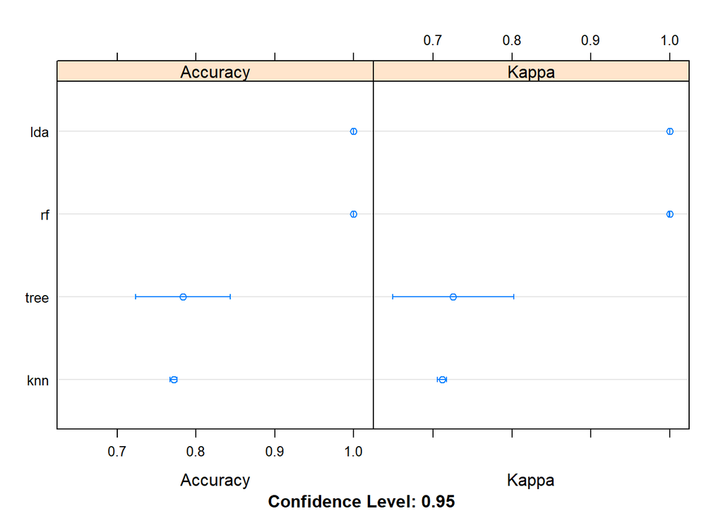

```r
dotplot(results)
```

We can see that LDA is slightely more accurate than RF.So we will go with Linear discriminative analysis.

The results for just the LDA model can be summarized.

```r
print(fitlda)
```

```
## Linear Discriminant Analysis
##
## 19622 samples
##    59 predictor
##     5 classes: 'A', 'B', 'C', 'D', 'E'
##
## No pre-processing
## Resampling: Cross-Validated (10 fold)
## Summary of sample sizes: 17660, 17659, 17659, 17660, 17659, 17662, ...
## Resampling results:
##
##   Accuracy   Kappa
##   0.9999491  0.9999356
```

# Predictions

Now lets run the LDA in the test data set.

```r
predictions <- predict(fitlda,test)
predictions
```

```
##  [1] A A A A A A A A A A A A A A A A A A A A
## Levels: A B C D E
```

This is the outcomes after the predictions performed by LDA.